# Figure S2

John Favate

2022-07-23 17:09:20

```r
# Prevent printing of warnings and such in the HTML
knitr::opts_chunk$set(warning = FALSE, message = FALSE, fig.align = "center")
```

```r
library(tidyverse)
library(patchwork)
library(broom)
library(ggrepel)
library(scales)
library(ggpubr)
library(grid)
library(gridExtra)
library(gtable)

all.data <- read_csv("../../data_frames/all_data.csv") %>%
  filter(gene_type == "ECB")%>%
  mutate(line = str_replace(line, "Ara-", "A-"),
         line = str_replace(line, "Ara\\+", "A+"))

# get the e coli proteins only
ecb.genes <- unique(all.data$target_id)

# Removes ERCC and tRNA genes from the data
kdf <- read_csv("../../data_frames/table_s1_read_counts.csv") %>%
  filter(target_id %in% ecb.genes)%>%
  mutate(line = str_replace(line, "Ara-", "A-"),
         line = str_replace(line, "Ara\\+", "A+"))

mut.levels <- all.data %>%
  select(line, mutator) %>%
  distinct() %>%
  arrange(mutator, line) %>%
  pull(line) %>%
  str_replace(., "Ara-", "A-") %>%
  str_replace("Ara\\+", "A+")

# deseq results
ddf <- read_csv("../../data_frames/table_s2_fold_changes.csv") %>%
  filter(seqtype == "rna") %>%
  mutate(line = str_replace(line, "Ara-", "A-"),
         line = str_replace(line, "Ara\\+", "A+"),
         line = factor(line, levels = mut.levels))
```

These are the mutator lines.

```r
mut.lines <- all.data %>%
  filter(mutator == TRUE) %>%
  pull(line) %>%
  unique()
```

Define the set of genes that were significant in any one line. This includes deletions as significant.

```r
sig.genes <- ddf %>%
  filter(padj <= .01 | deleted == TRUE) %>%
  pull(target_id) %>%
  unique()
```

### Panel A

Full fold change distribution

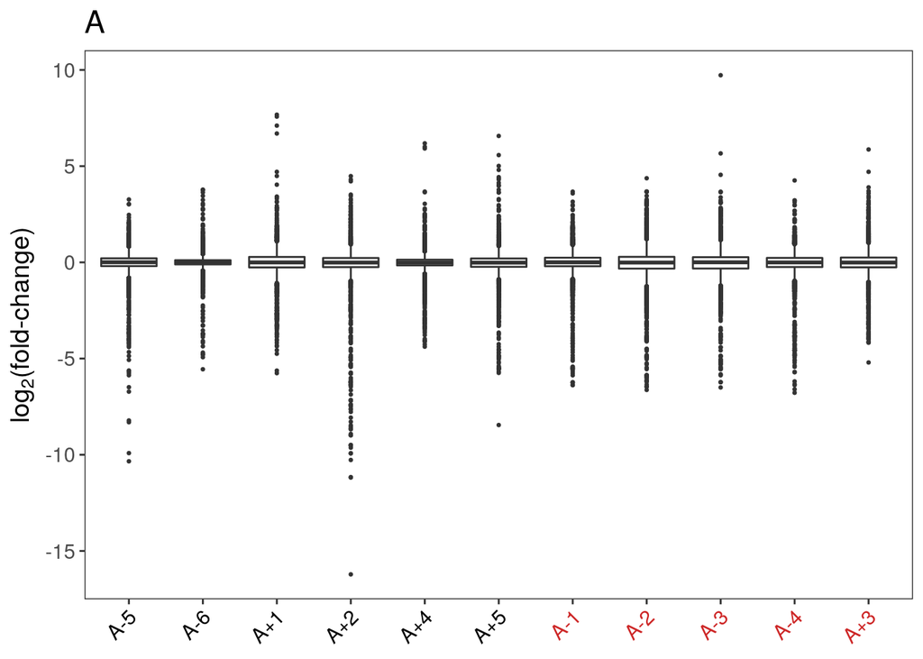

```r
fc.only <- all.data %>%
  filter(gene_type == "ECB") %>%
  select(line, ds_log2foldchange_rna) %>%
  mutate(line = factor(line, mut.levels))

mut.colors.a <- c(rep("black", 6), rep("firebrick3", 5))

pa <- fc.only %>%
  ggplot(., aes(line, ds_log2foldchange_rna)) +
  geom_boxplot(outlier.size = .5) +
  theme_bw() +
  theme(
    text = element_text(size = 14),
    panel.grid = element_blank(),
    axis.text.x = element_text(
      angle = 45,
      vjust = 1.1,
      hjust = 1.1,
      color = mut.colors.a
    )
  ) +
  labs(x = NULL,
       y = expression(paste(log[2], "(fold-change)")),
       title = "A") +
  scale_y_continuous(breaks = seq(-15, 15, 5))

pa
```

### Panel B

Number of sig genes per line

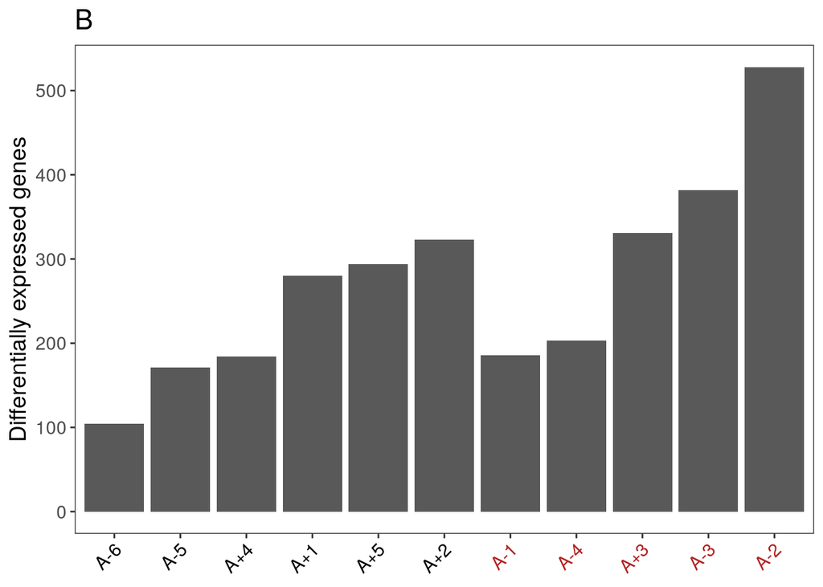

```r
bdf <- all.data %>%
  filter(ds_padj_rna <= .01) %>%
  group_by(line) %>%
  tally()

# order lines by mutator/n genes
b.order <- bdf %>%
  mutate(mutator = line %in% mut.lines) %>%
  arrange(mutator, n) %>%
  pull(line)

# order it
bdf$line <- factor(bdf$line, b.order)

# determine axis text color
b.colors <- sapply(b.order, function(x){
  if (x %in% mut.lines){
    return("firebrick")
  } else {
    return("black")
  }
})

pb <- bdf %>%
  ggplot(., aes(line, n))+
  geom_col()+
  theme_bw()+
  theme(panel.grid = element_blank(),
        text = element_text(size = 14),
        legend.position = c(.5, .95),
        legend.direction = "horizontal",
        legend.background = element_blank(),
        axis.text.x = element_text(color = b.colors, angle = 45, vjust = 1.1, hjust = 1.1))+
  labs(x = NULL,
       y = "Differentially expressed genes",
       title = "B")+
  scale_y_continuous(breaks = breaks_pretty(n = 6))

pb
```

### Figure C

```r
count.cis <- read_csv("../../data_frames/count_cis.csv") %>%
  mutate(type = "Randomized") %>%
  select(direc, n, mean_prob, type) %>%
  rename("prob" = "mean_prob")
```

Load the probabilities from figure 1

```r
f1.probs <- read_rds("../../data_frames/fig_1_probs.rds") %>%
  select(n, starts_with("Exp")) %>%
  pivot_longer(starts_with("Exp"), names_to = "direc", values_to = "prob") %>%
  mutate(type = "SINIB",
         direc = str_remove(direc, "\\w+_"))
```

Combine them

```r
pc.df1 <- bind_rows(f1.probs, count.cis) %>%
  filter(n != 0) %>%
  unite("ltype", type, direc, sep = " ") %>%
  mutate(prob = ifelse(prob == 0, NA, prob))
```

KS test them

```r
ksdf <- pc.df1 %>%
  pivot_wider(names_from = ltype, values_from = prob)

p.up <- signif(ks.test(ksdf$`SINIB up`, ksdf$`Randomized up`)$p.value, 3)

p.down <- signif(ks.test(ksdf$`SINIB down`, ksdf$`Randomized down`)$p.value, 3)
```

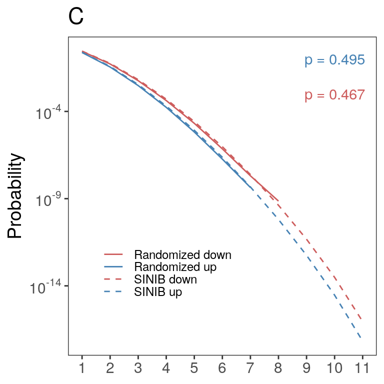

```r
pc.top <- pc.df1 %>%
  ggplot(., aes(n, prob, color = ltype, linetype = ltype)) +
  geom_line() +
  scale_y_log10(labels = trans_format("log10", math_format(10 ^ .x))) +
  scale_x_continuous(breaks = 1:11, name = NULL) +
  scale_color_manual(values = rep(c("indianred", "steelblue"), 2), name = NULL) +
  scale_linetype_manual(values = c(1, 1, 2, 2), name = NULL) +
  theme_bw() +
  theme(
    text = element_text(size = 14),
    panel.grid = element_blank(),
    legend.position = c(.32, .26),
    legend.text = element_text(size = 9),
    legend.key = element_blank(),
    legend.background = element_blank(),
    legend.spacing.y = unit(.1, "mm"),
    legend.key.height = unit(3, "mm")
  ) +
  labs(x = "Number of lines",
       y = "Probability",
       title = "C") +
  guides(color = guide_legend(byrow = TRUE))+
  annotate("text", label = paste("p =", p.up), x = 10, y = .1, color = "steelblue")+
  annotate("text", label = paste("p =", p.down), x = 10, y = .001, color = "indianred")

pc.top
```

The lower part

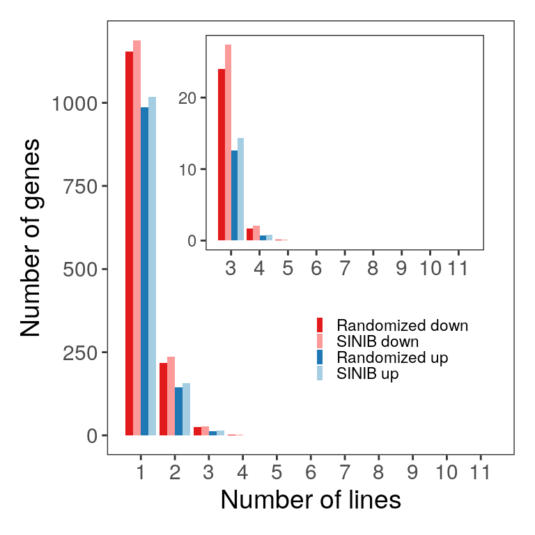

```r
pc.df2 <- bind_rows(f1.probs, count.cis) %>%
  filter(n != 0) %>%
  unite("ltype", type, direc, sep = " ") %>%
  mutate(prob = ifelse(prob == 0, NA, prob),
         n_genes = prob * length(unique(ddf$target_id)),
         ltype = factor(ltype, c("Randomized down", "SINIB down", "Randomized up", "SINIB up")))

colorz <- c("#E31A1C", "#FB9A99", "#1F78B4", "#A6CEE3")

inset <- pc.df2 %>%
  filter(n >= 3) %>%
  ggplot(., aes(n, n_genes, fill = ltype))+
  geom_col(position = "dodge")+
  scale_x_continuous(breaks = 1:11)+
  scale_y_continuous(breaks = c(0, 10, 20))+
  scale_fill_manual(values = colorz, name = NULL, guide ="none")+
  theme_bw()+
  theme(text = element_text(size = 14),
        panel.grid = element_blank(),
        legend.background = element_blank(),
        legend.position = c(.7, .8),
        plot.background = element_blank(),
        axis.text.y = element_text(size = 9))+
  labs(x = NULL, y= NULL)

pc.big <- pc.df2 %>%
  ggplot(., aes(n, n_genes, fill = ltype))+
  geom_col(position = "dodge")+
  scale_x_continuous(breaks = 1:11)+
  scale_fill_manual(values = colorz, name = NULL)+
  theme_bw()+
  theme(text = element_text(size = 14),
        panel.grid = element_blank(),
        legend.background = element_blank(),
        legend.position = c(.7, .25),
        legend.text = element_text(margin = margin(l = .001, unit = "mm"), size = 8.5),
        legend.key.size = unit(1.5, "mm"),
        legend.spacing.y = unit(1, 'mm'))+
  labs(x = "Number of lines",
       y = "Number of genes")

pc.bottom <- pc.big + inset_element(inset, left = .15, right = .95, top = .99, bottom = .38)

pc.bottom
```

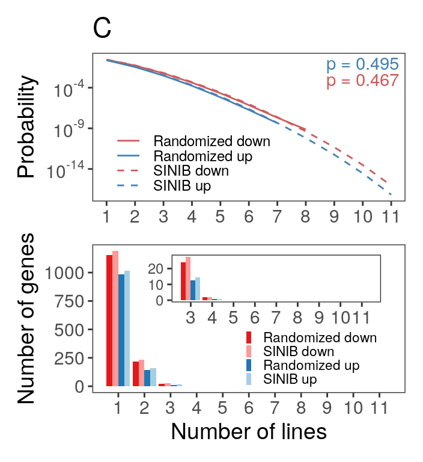

```r
pc.full <- pc.top / pc.bottom

pc.full
```

### Panel D

A boxplot that shows the number, magnitude, and direction of fold changes per line.

```r
fc.count.df <- ddf %>%
  filter(padj <= sig) %>%
  mutate(direc = ifelse(log2FoldChange > 0, "Upregulated", "Downregulated")) %>%
  group_by(line, direc) %>%
  summarise(n = n()) %>%
  group_by(line) %>%
  mutate(prop = signif(n / sum(n), 2),
         total = sum(n))
```

A set of binomial tests to show that the number of up and down genes is different.

```r
fc.count.df %>%
  select(-prop) %>%
  pivot_wider(names_from = direc, values_from = n) %>%
  split(.$line) %>%
  map(function(x){
    binom.test(x$Downregulated, x$total, alternative = "greater") %>%
      tidy()
  }) %>%
  bind_rows(.id = "line") %>%
  mutate(sig = p.value <= .05) %>%
  group_by(sig) %>%
  tally()
```

| sig | n |
| --- | --- |
| FALSE | 4 |
| TRUE | 7 |

stat_compare_means can’t use a KS test, perform one manually and manually add the stars.

```r
pval.df <- ddf %>%
  filter(padj <= sig) %>%
  mutate(direc = ifelse(log2FoldChange > 0, "Upregulated", "Downregulated")) %>%
  select(line, target_id, log2FoldChange, direc) %>%
  pivot_wider(names_from = direc, values_from = log2FoldChange) %>%
  split(.$line) %>%
  map(function(x) {
    ks.test(na.omit(x$Downregulated), na.omit(x$Upregulated), exact = TRUE) %>%
      tidy()
  }) %>%
  bind_rows(.id = "line") %>%
  mutate(cuts = cut(
    p.value,
    c(1, .05, .01, .001, .0001,-Inf),
    labels = c("****", "***", "**", "*", "NS")
  ))

pval.df
```

| line | statistic | p.value | method | alternative | cuts |
| --- | --- | --- | --- | --- | --- |
| A-5 | 1 | 6.039613e-14 | Exact two-sample Kolmogorov-Smirnov test | two-sided | **** |
| A-6 | 1 | 0.000000e+00 | Exact two-sample Kolmogorov-Smirnov test | two-sided | **** |
| A+1 | 1 | 0.000000e+00 | Exact two-sample Kolmogorov-Smirnov test | two-sided | **** |
| A+2 | 1 | 0.000000e+00 | Exact two-sample Kolmogorov-Smirnov test | two-sided | **** |
| A+4 | 1 | 7.382983e-14 | Exact two-sample Kolmogorov-Smirnov test | two-sided | **** |
| A+5 | 1 | 0.000000e+00 | Exact two-sample Kolmogorov-Smirnov test | two-sided | **** |
| A-1 | 1 | 7.926992e-14 | Exact two-sample Kolmogorov-Smirnov test | two-sided | **** |
| A-2 | 1 | 0.000000e+00 | Exact two-sample Kolmogorov-Smirnov test | two-sided | **** |
| A-3 | 1 | 2.027267e-13 | Exact two-sample Kolmogorov-Smirnov test | two-sided | **** |
| A-4 | 1 | 0.000000e+00 | Exact two-sample Kolmogorov-Smirnov test | two-sided | **** |

[output cut: 1 more lines]

A box plot showing the significant fold changes

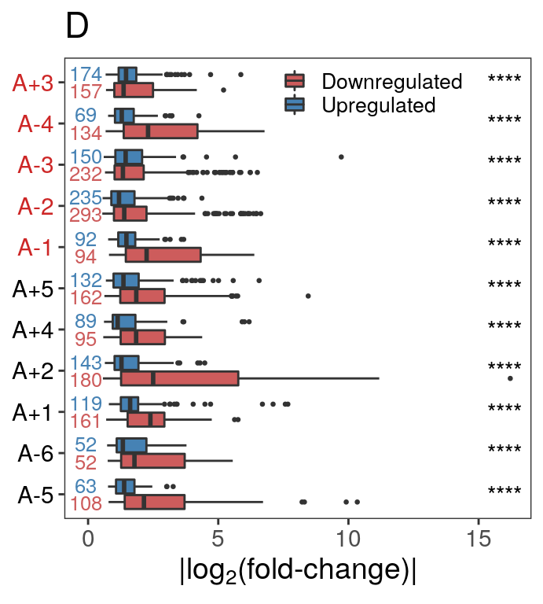

```r
mut.colors.d <- c(rep("black", 6), rep("firebrick3", 5))

pd <- ddf %>%
  filter(padj <= sig) %>%
  mutate(direc = ifelse(log2FoldChange > 0, "Upregulated", "Downregulated")) %>%
  ggplot(., aes(line, abs(log2FoldChange), fill = direc))+
  geom_boxplot(outlier.size = .5)+
  geom_text(inherit.aes = FALSE, data = fc.count.df, aes(x = line, y = -.1, color = direc, label = n), position = position_dodge(width = .85), size = 3.4)+
  scale_fill_manual(name = NULL, values = c("indianred", "steelblue"))+
  scale_color_manual(name = NULL, values = c("indianred", "steelblue"), guide = "none")+
  theme_bw()+
  theme(text = element_text(size = 14),
        panel.grid = element_blank(),
        legend.position = c(.66, .94),
        axis.text.y = element_text(color = mut.colors.d),
        legend.background = element_blank(),
        legend.text = element_text(size = 10),
        legend.key.size = unit(4, "mm"))+
  labs(x = NULL,
       y = expression(paste("|", log[2], "(fold-change)|")),
       title = "D")+
  guides(fill = guide_legend(nrow = 1))+
  geom_text(data = pval.df, aes(x = line, y = 16, label = cuts), inherit.aes = FALSE)+
  guides(fill=guide_legend(ncol=1))+
  coord_flip()

pd
```

### Panel E

A PCA using all fold-changes, with deletions given a value of -10 for two reasons. One, the PCA needs complete data and deleted genes have fold-change of 0. Two, the deleted genes are treated as highly downregulated because they’re either completely absent or pseudogenized and don’t produce functional proteins.

```r
# genes deleted in all have to be removed, PCA can't scale a column with 0 variance
good.genes <- all.data %>%
  filter(deleted == TRUE) %>%
  group_by(target_id) %>%
  tally() %>%
  filter(n != 11) %>%
  pull(target_id)

pca.input <- all.data %>%
  select(line, target_id, ds_log2foldchange_rna, deleted) %>%
  filter(target_id %in% good.genes) %>%
  mutate(ds_log2foldchange_rna = ifelse(deleted == TRUE, -10, ds_log2foldchange_rna)) %>%
  select(-deleted) %>%
  pivot_wider(names_from = target_id, values_from = ds_log2foldchange_rna) %>%
  column_to_rownames("line") %>%
  .[ , colSums(is.na(.)) == 0] # some genes have NAs as fold-changes anyway, remove those
```

```r
pca.results <- prcomp(pca.input, scale = TRUE)
```

Determine the variance explained

```r
var.explained <- pca.results %>%
  tidy(matrix = "eigenvalues")

pc1.explain <- paste0("PC1 (", 100*signif(var.explained[var.explained$PC == 1,]$percent, 4), "%)")

pc2.explain <- paste0("PC2 (", 100*signif(var.explained[var.explained$PC == 2,]$percent, 4), "%)")
```

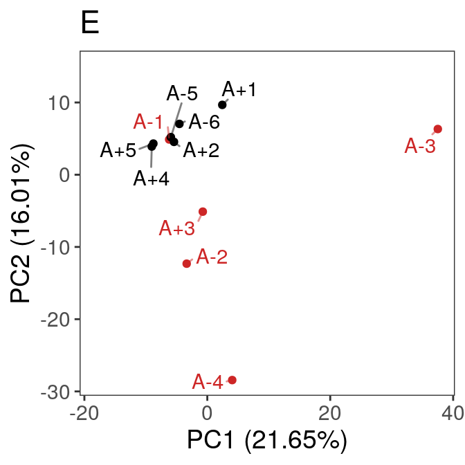

```r
pe <- pca.results %>%
  augment(pca.input) %>%
  rename("line" = ".rownames") %>%
  mutate(mutator = line %in% mut.lines) %>%
  ggplot(aes(.fittedPC1, .fittedPC2, label = line, color = mutator))+
  geom_point()+
  geom_text_repel(min.segment.length = .0001, max.overlaps = Inf, segment.alpha = .5)+
  theme_bw()+
  theme(text = element_text(size = 14),
        panel.grid = element_blank())+
  labs(x = pc1.explain,
       y = pc2.explain,
       title = "E")+
  scale_color_manual(values = c("black", "firebrick3"), guide = "none")+
  expand_limits(y = c(0, 15), x = c(-18, 0))

pe
```

How does -1:-10 affect the results?

```r
pca.p.list <- lapply(-10:-1, function(x) {
  pca.input <- all.data %>%
    select(line, target_id, ds_log2foldchange_rna, deleted) %>%
    filter(target_id %in% good.genes) %>%
    mutate(ds_log2foldchange_rna = ifelse(deleted == TRUE, x, ds_log2foldchange_rna)) %>%
    select(-deleted) %>%
    pivot_wider(names_from = target_id, values_from = ds_log2foldchange_rna) %>%
    column_to_rownames("line") %>%
    .[, colSums(is.na(.)) == 0] # some genes have NAs as fold-changes anyway, remove those

  pca.results <- prcomp(pca.input, scale = TRUE)

  var.explained <- pca.results %>%
    tidy(matrix = "eigenvalues")

  pc1.explain <-
    paste0("PC1 (", 100 * signif(var.explained[var.explained$PC == 1, ]$percent, 4), "%)")

  pc2.explain <-
    paste0("PC2 (", 100 * signif(var.explained[var.explained$PC == 2, ]$percent, 4), "%)")

  pca.results %>%
    augment(pca.input) %>%
    rename("line" = ".rownames") %>%
    mutate(mutator = line %in% mut.lines) %>%
    ggplot(aes(.fittedPC1, .fittedPC2, label = line, color = mutator)) +
    geom_point() +
    geom_text_repel(
      min.segment.length = .0001,
      max.overlaps = Inf,
      segment.alpha = .5
    ) +
    theme_bw() +
    theme(text = element_text(size = 14),
          panel.grid = element_blank()) +
    labs(x = pc1.explain,
         y = pc2.explain,
         title = x) +
    scale_color_manual(values = c("black", "firebrick3"), guide = "none") +
    expand_limits(y = c(0, 15), x = c(-18, 0))
})
```

Seems like it doesn’t affect the distribution of the points too much.

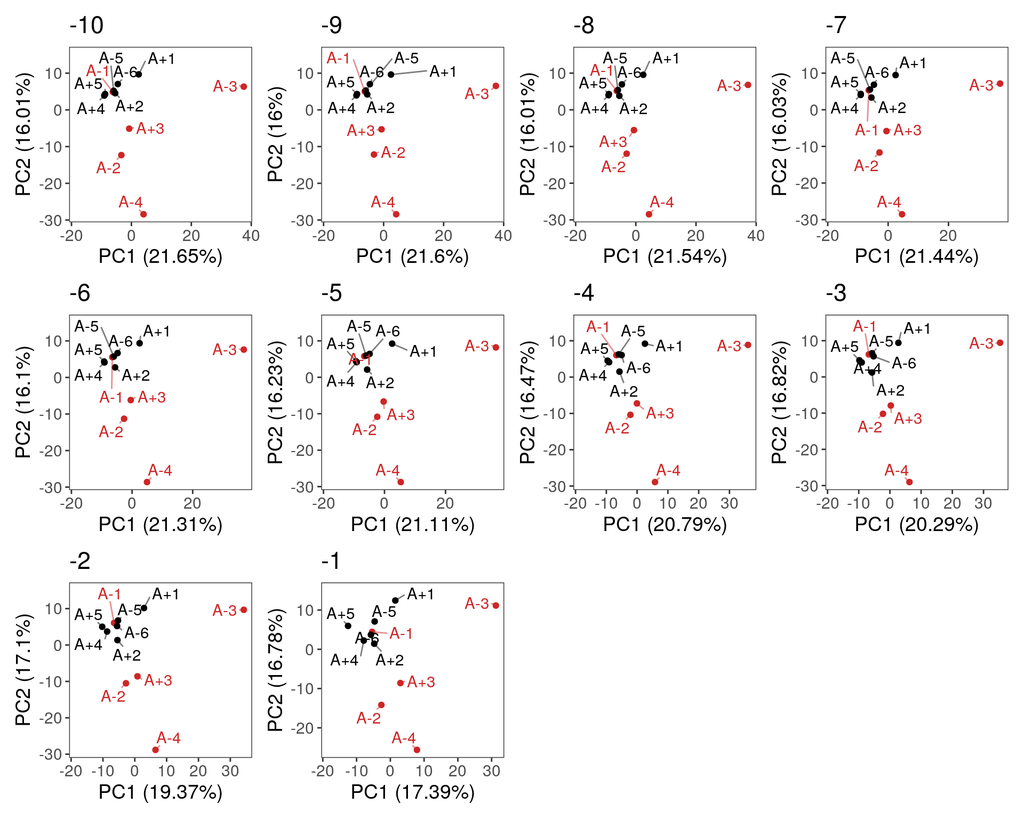

```r
wrap_plots(pca.p.list)
```

### Panel F

Check the contributors to PC1 and PC2

```r
top.10.pc1 <- pca.results %>%
  tidy(matrix = "rotation") %>%
  pivot_wider(names_from = PC, values_from = value) %>%
  arrange(desc(abs(`1`))) %>%
  pull(column) %>%
  .[1:10]

top.10.pc2 <- pca.results %>%
  tidy(matrix = "rotation") %>%
  pivot_wider(names_from = PC, values_from = value) %>%
  arrange(desc(abs(`2`))) %>%
  pull(column) %>%
  .[1:10]
```

```r
threshold <- 3

scale.labels <- c(paste("\u2264", paste0("-", threshold), sep = ""),
                  "",
                  0,
                  "",
                  paste("\u2265", threshold, sep = ""))
```

```r
names.df <- all.data %>%
  select(target_id, rel_name) %>%
  distinct()

hm.df <- ddf %>%
  filter(target_id %in% c(top.10.pc1, top.10.pc2)) %>%
  mutate(
    pc = ifelse(target_id %in% top.10.pc1, "PC1", "PC2"),
    stars = ifelse(padj <= .01, "*", NA),
    line = factor(line, mut.levels),
    newfc = case_when(
      log2FoldChange < -3 ~ -3,
      log2FoldChange > 3 ~ 3,
      is.na(log2FoldChange) | TRUE ~ log2FoldChange
    )
  ) %>%
  select(line, target_id, newfc, padj, pc, stars) %>%
  left_join(names.df)
```

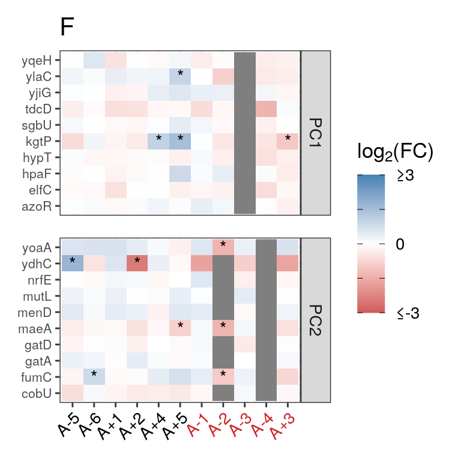

```r
pf <- hm.df %>%
  split(.$pc) %>%
  map(function(x) {
    ggplot(x, aes(line, rel_name, fill = newfc, label = stars)) +
      geom_raster() +
      scale_fill_gradientn(
        colors = c("indianred", "white", "steelblue"),
        labels = scale.labels,
        breaks = c(-3, -1.5, 0, 1.5, 3),
        name = expression(paste(log[2], "(FC)")),
        guide = guide_colorbar(ticks.colour = "black"),
        limits = c(-3, 3)
      ) +
      geom_text() +
      facet_wrap( ~ pc, ncol = 1, scales = "free", strip.position = "right") +
      theme_bw() +
      theme(
        axis.text.x = element_text(angle = 45, hjust = 1, color = mut.colors.a),
        text = element_text(size = 13),
        axis.text.y = element_text(size = 8)
      ) +
      labs(x = NULL, y = NULL)
  })

pf.top <- pf$PC1 + theme(axis.text.x = element_blank(),
                         axis.ticks.x = element_blank())+ labs(title = "F")

pf.bottom <- pf$PC2 + guides(fill = "none")

pf.full <- (pf.top / pf.bottom) + plot_layout(guides = "collect")

pf.full
```

### Panel G

The table underneath to show the gene names and what they do

```r
str_clean_func <- function(x){
  x %>%
    str_remove_all("\\&") %>%
    str_remove_all("\\;") %>%
    str_remove_all("\\<sup\\>") %>%
    str_remove_all("\\<\\/sup\\>")
}

ttt <- ttheme_default(core=list(fg_params=list(hjust=0, x=.01, cex = .7)),
                      rowhead=list(fg_params=list(hjust=0, x=0)))

table.title <- textGrob("G",gp=gpar(fontsize=17))

t1 <- all.data %>%
  filter(target_id %in% c(top.10.pc1)) %>%
  select(target_id, rel_name, rel_product) %>%
  unique() %>%
  mutate(target_id = factor(target_id, levels = c(top.10.pc1))) %>%
  arrange(target_id) %>%
  select(-target_id) %>%
  rename("PC1 genes" = "rel_name", "Product" = "rel_product") %>%
  mutate(Product = str_clean_func(Product)) %>%
  tableGrob(theme = ttt, rows = NULL)

t1 <- gtable_add_rows(
  t1, heights = grobHeight(table.title) + unit(0.5,"line"), pos = 0
)

t1 <- gtable_add_grob(t1,
                      list(table.title),
                      t = 1,
                      l = 1)

blank <- textGrob(" ",gp=gpar(fontsize=17))

t2 <- all.data %>%
  filter(target_id %in% c(top.10.pc2)) %>%
  select(target_id, rel_name, rel_product) %>%
  unique() %>%
  mutate(target_id = factor(target_id, levels = c(top.10.pc2))) %>%
  arrange(target_id) %>%
  select(-target_id) %>%
  rename("PC2 genes" = "rel_name", "Product" = "rel_product") %>%
  mutate(Product = str_clean_func(Product)) %>%
  tableGrob(theme = ttt, rows = NULL)

t2 <- gtable_add_rows(
  t2, heights = grobHeight(blank) + unit(0.5,"line"), pos = 0
)

t2 <- gtable_add_grob(t2,
                      list(blank),
                      t = 1,
                      l = 1)
```

### Final figure

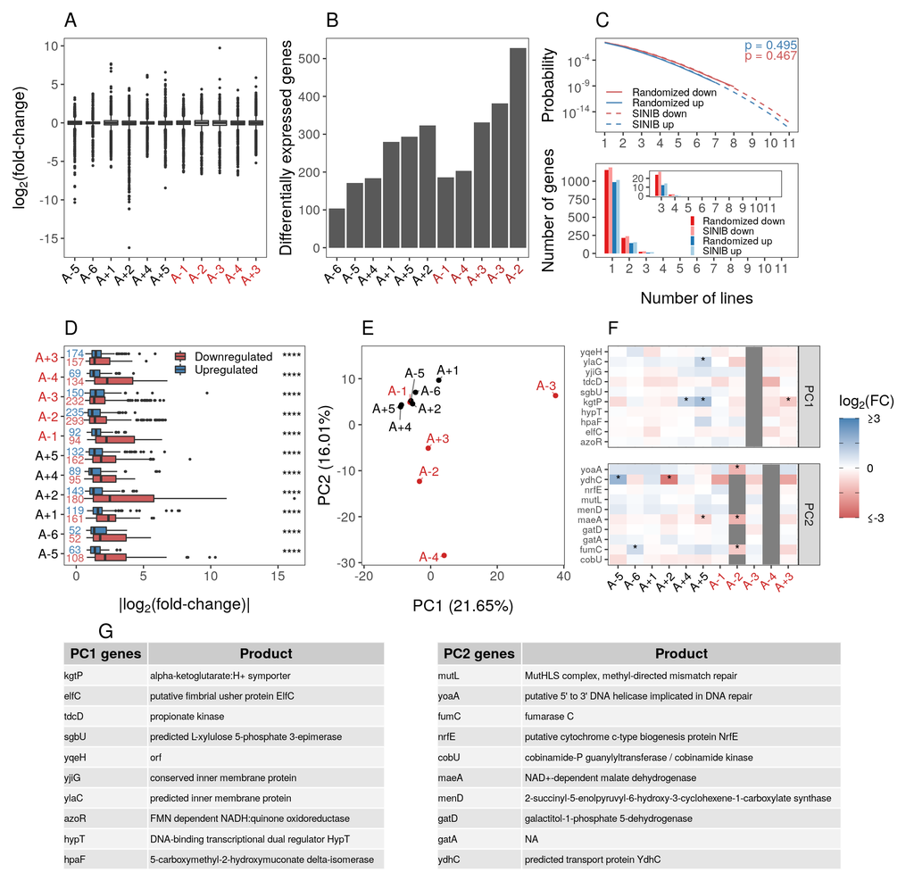

```r
top <- (pa | pb | pc.full)

middle <- (pd | pe | pf.full) + plot_layout(widths = c(.38, .32, .3))

bottom <- (plot_spacer() | t1 | t2) + plot_layout(widths = c(.01, .4, .6))

(ff <- (top / middle / bottom) + plot_layout(heights = c(.325, .325, .34)))
```

Save it

```r
write_rds(ff, "../../figures/fig_s2.rds")

ggsave(ff, filename = "../../figures/fig_s2.pdf", width = 11, height = 10.5)

ggsave(ff, filename = "../../figures/fig_s2.png", width = 11, height = 10.5)
```